# An R Markdown document converted from “property.ipynb”

# Plotting a Property Dataset

KATE expects your code to define variables with specific names that correspond to certain things we are interested in.

KATE will run your notebook from top to bottom and check the latest value of those variables, so make sure you don’t overwrite them.

- Remember to uncomment the line assigning the variable to your answer and don’t change the variable or function names.
- Use copies of the original or previous DataFrames to make sure you do not overwrite them by mistake.

You will find instructions below about how to define each variable.

Once you’re happy with your code, upload your notebook to KATE to check your feedback.

Run the following cell to import packages and set plotting styling.

**The plotting styling should not be changed**; doing so may result in KATE incorrectly evaluating your plots.

*Note: `matplotlib` does a lot of work in the background to “guess” what figure to plot on. This can have the effect of modifying figures you have created before in the notebook, which will cause your plots to be wrong on KATE. To ensure your plots are always created properly, call `plt.figure()` before each command that creates a new plot, this will ensure you plot on a new figure everytime.*

```r
library("tidyverse") #mainly for dplyr
library("highcharter") # date manipulation
library("glue") # literal string manipulation
library("collapse") # fast data transformation and aggregateion
library("fs") # file system operations
library("ragg") # resizing graphics output
library("plotly") # making plots interactive
library("reticulate") # python in Rstudio
#use_condaenv("ds01") # data science conda environment
use_condaenv("py38") # need python 3.8 for bokeh
```

```python
import pandas as pd
import seaborn as sns
import matplotlib.pyplot as plt
sns.set()

from matplotlib.axes._axes import _log as matplotlib_axes_logger
matplotlib_axes_logger.setLevel('ERROR') #prevents unnecessary mpl warnings about sns color palette
```

```python
df = pd.read_csv('data/assessments.csv')
```

```r
df <- read_csv("data/assessments.csv")
```

The `data-dictionary.pdf` file provided gives details about each field.

## Charting residential properties with pandas

**Q1.** Create a DataFrame containing only properties from `df` with a `CLASSDESC` of `RESIDENTIAL`. Store the answer in a variable called `res`

```python
df.head()
```

```
##       PROPERTYADDRESS PROPERTYCITY  ...  FIREPLACES BSMTGARAGE
## 0            GRANT ST   PITTSBURGH  ...         NaN        NaN
## 1  FORT DUQUESNE BLVD   PITTSBURGH  ...         0.0        0.0
## 2  FORT DUQUESNE BLVD   PITTSBURGH  ...         0.0        0.0
## 3         SMALLMAN ST   PITTSBURGH  ...         NaN        NaN
## 4         SMALLMAN ST   PITTSBURGH  ...         NaN        NaN
##
## [5 rows x 47 columns]
```

```python
#add your code below...
res = df[df.CLASSDESC == 'RESIDENTIAL']
```

```r
res <- df %>%
    filter(CLASSDESC == "RESIDENTIAL")
```

**Q2.** Create a DataFrame containing only properties from `res` with `BEDROOMS` greater than 0 and less than 7.

- Use the `.copy()` method so that you have a distinct DataFrame in memory
- Use the `.notnull()` method to mask out the rows in `BEDROOMS` which are null
- Use the `.astype()` method to change the data type of the `BEDROOMS` column to `int`
- Filter the new DataFrame to only contain rows where `BEDROOMS` is greater than `0` and less than `7`

Call the new dataframe `res_16`

```python
# Add your code below
res_16 = res.copy()[res['BEDROOMS'].notnull()] \
.astype({'BEDROOMS': int}) \
[res['BEDROOMS'] > 0][res['BEDROOMS'] < 7]
res_16
```

```
##          PROPERTYADDRESS   PROPERTYCITY  ...  FIREPLACES BSMTGARAGE
## 1     FORT DUQUESNE BLVD     PITTSBURGH  ...         0.0        0.0
## 2     FORT DUQUESNE BLVD     PITTSBURGH  ...         0.0        0.0
## 3            SMALLMAN ST     PITTSBURGH  ...         NaN        NaN
## 4            SMALLMAN ST     PITTSBURGH  ...         NaN        NaN
## 5            SMALLMAN ST     PITTSBURGH  ...         NaN        NaN
## ...                  ...            ...  ...         ...        ...
## 1644         PHILLIPS LN  MC KEES ROCKS  ...         1.0        2.0
## 1645           REITER RD     PITTSBURGH  ...         1.0        3.0
## 1646     SILVER PINES DR       GIBSONIA  ...         NaN        NaN
## 1647         HIGHVIEW DR     PITTSBURGH  ...         1.0        2.0
## 1649        TRAILSIDE CT     CORAOPOLIS  ...         NaN        2.0
##
## [1304 rows x 47 columns]
```

```r
res_16 <- res %>%
    filter(between(BEDROOMS, 1, 6),
           !is.na(BEDROOMS)) %>%
    mutate(BEDROOMS = as.integer(BEDROOMS))
res_16
```

```
## # A tibble: 1,304 × 47
##    PROPERTYADD…¹ PROPE…² PROPE…³ MUNID…⁴ SCHOO…⁵ NEIGH…⁶ TAXDESC OWNER…⁷ CLASS…⁸
##    <chr>         <chr>     <dbl> <chr>   <chr>   <chr>   <chr>   <chr>   <chr>
##  1 FORT DUQUESN… PITTSB…   15222 2nd Wa… City O… PENNHO… 20 - T… REGULA… RESIDE…
##  2 FORT DUQUESN… PITTSB…   15222 2nd Wa… City O… PENNHO… 20 - T… REGULAR RESIDE…
##  3 SMALLMAN ST   PITTSB…   15222 2nd Wa… City O… STRIP … 20 - T… REGULAR RESIDE…
##  4 SMALLMAN ST   PITTSB…   15222 2nd Wa… City O… STRIP … 20 - T… REGULA… RESIDE…
##  5 SMALLMAN ST   PITTSB…   15222 2nd Wa… City O… STRIP … 20 - T… REGULAR RESIDE…
##  6 SMALLMAN ST   PITTSB…   15222 2nd Wa… City O… STRIP … 20 - T… REGULA… RESIDE…
##  7 SMALLMAN ST   PITTSB…   15222 2nd Wa… City O… STRIP … 20 - T… REGULA… RESIDE…
##  8 SMALLMAN ST   PITTSB…   15222 2nd Wa… City O… STRIP … 20 - T… REGULAR RESIDE…
##  9 SMALLMAN ST   PITTSB…   15222 2nd Wa… City O… STRIP … 20 - T… REGULAR RESIDE…
## 10 LIBERTY AVE   PITTSB…   15222 2nd Wa… City O… KEYSTO… 20 - T… REGULA… RESIDE…
## # … with 1,294 more rows, 38 more variables: USEDESC <chr>, LOTAREA <dbl>,
## #   HOMESTEADFLAG <chr>, ABATEMENTFLAG <lgl>, RECORDDATE <chr>, SALEDATE <chr>,
## #   SALEPRICE <dbl>, SALEDESC <chr>, PREVSALEDATE <chr>, PREVSALEPRICE <dbl>,
## #   COUNTYBUILDING <dbl>, COUNTYLAND <dbl>, COUNTYTOTAL <dbl>,
## #   COUNTYEXEMPTBLDG <dbl>, LOCALBUILDING <dbl>, LOCALLAND <dbl>,
## #   LOCALTOTAL <dbl>, FAIRMARKETBUILDING <dbl>, FAIRMARKETLAND <dbl>,
## #   FAIRMARKETTOTAL <dbl>, STYLEDESC <chr>, STORIES <dbl>, YEARBLT <dbl>, …
## # ℹ Use `print(n = ...)` to see more rows, and `colnames()` to see all variable names
```

**Q3.** Use `.groupby()` on `res_16` to create a Series with an index of `BEDROOMS` and values of the `.mean()` of `FULLBATHS` for each number of `BEDROOMS`.

Assign this series to a new variable called `bed_bath`

```python
# Add your code below
bed_bath = res_16.groupby('BEDROOMS')['FULLBATHS'].mean()
bed_bath.head(8)
```

```
## BEDROOMS
## 1    1.030303
## 2    1.173469
## 3    1.354132
## 4    2.236301
## 5    2.925926
## 6    3.552632
## Name: FULLBATHS, dtype: float64
```

```r
bed_bath <- res_16 %>%
    group_by(BEDROOMS) %>%
    summarise(FULLBATHS = mean(FULLBATHS, na.rm = TRUE))
bed_bath
```

```
## # A tibble: 6 × 2
##   BEDROOMS FULLBATHS
##      <int>     <dbl>
## 1        1      1.03
## 2        2      1.17
## 3        3      1.35
## 4        4      2.24
## 5        5      2.93
## 6        6      3.55
```

**Q4.** Use the `.plot()` method on `bed_bath` to create a plot of `kind='line'`.

- This should result in a plot of `BEDROOMS` on the x-axis with the average number of `FULLBATHS` on the y-axis
- Save your plot into a new variable, `bb_line`

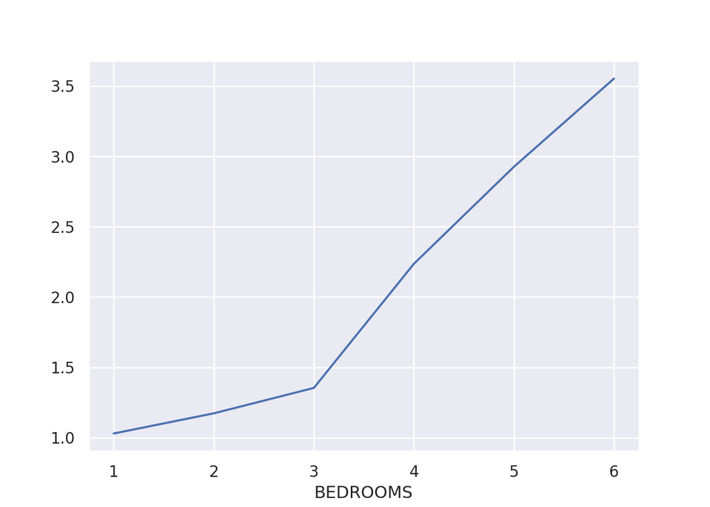

```python
# We create a new figure to make other figures in the notebook don't get modified
plt.figure()
# Add your code below
bb_line = bed_bath.plot(kind = 'line')
# appears in plot window
plt.show()
```

```r
# highcharter
bed_bath %>%
    hchart("line", hcaes(x = BEDROOMS, y = FULLBATHS)) %>%
    hc_title(text = "Relationship between Bedrooms and Bathrooms")
```

[interactive chart not shown]

**Q5.** Using the `res_16` DataFrame, create a Series with an index of `BEDROOMS` and values of the `.value_counts()` of each number, using `.sort_index()` to order it by the index.

Call the new variable `beds`

```python
# Add your code below
beds= res_16.BEDROOMS.value_counts().sort_index()
beds
```

```
## 1     33
## 2    294
## 3    593
## 4    292
## 5     54
## 6     38
## Name: BEDROOMS, dtype: int64
```

```r
beds <- res_16 %>%
    count(BEDROOMS)
```

**Q6.** Use the `.plot()` method on `beds` to create a plot of `kind='bar'`, with variable `bar_title` as the `title`.

Save your plot into a variable called `beds_bar`

```python
bar_title = 'Residential housing by number of bedrooms'
```

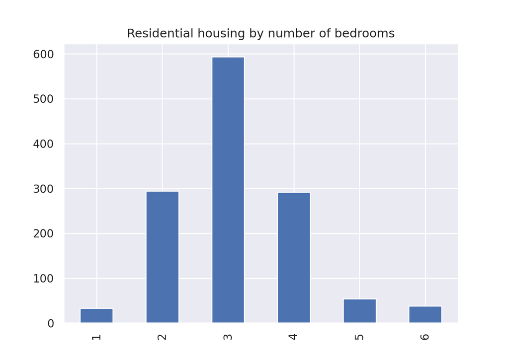

```python
plt.figure()
beds_bar = beds.plot(title = bar_title, kind = 'bar')
plt.show()
```

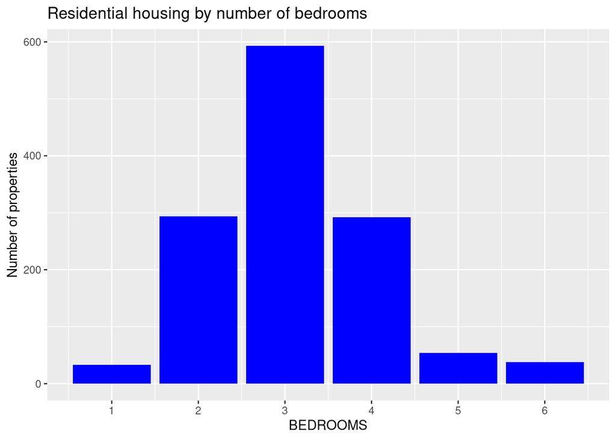

```r
beds_bar <- beds %>%
    ggplot() +
    geom_col(aes(x = BEDROOMS, y = n), fill = "blue") +
    labs(title = py$bar_title,
         y = "Number of properties") +
scale_x_continuous(breaks = beds$BEDROOMS)

beds_bar
```

```r
# highcharter
beds %>%
    hchart("column", hcaes(x = BEDROOMS, y = n)) %>%
    hc_title(text = py$bar_title) %>%
    hc_yAxis(title = list(text = "Number of properties")) %>%
    hc_xAxis(title = list(text = "Bedrooms"))
```

[interactive chart not shown]

**Q7.** Create a function called `zip_land` which takes two arguments: a DataFrame (with the same columns as `df`) and an integer (which it can be assumed will always be present in the `PROPERTYZIP` column of the DataFrame).

- This function will need to filter down the `df` argument to the rows where the `PROPERTYZIP` column is equal to the `zip_code` argument, before returning a `scatter` plot with the following properties:
  - `x=LOTAREA`
  - `y=FAIRMARKETLAND`
  - `xlim` and `ylim` both from `0` to double the `.mean()` of the respective column values
  - `alpha` = 0.4
  - `figsize` = (12, 10)

Note: make sure you return the plot. You should have in your code something like `my_plot = [command to plot]` and then `return my_plot`

```python
# Add your code below to implement zip_land
def zip_land(df, zip_code):
    filt_df = df[df['PROPERTYZIP'] == zip_code]
    xlim_max = filt_df.LOTAREA.mean() * 2
    ylim_max = filt_df.FAIRMARKETLAND.mean() * 2
    theplot = filt_df.plot(x = 'LOTAREA',
                           y = 'FAIRMARKETLAND',
                           xlim = (0, xlim_max),
                           ylim = (0, ylim_max),
                           alpha = 0.4,
                           figsize = (12, 10),
                            kind = 'scatter')
    return theplot
```

```r
zip_land <- function(df, zip_code)
    {
    filt_df <- df %>%
        filter(PROPERTYZIP == zip_code)
    xlim_max = (filt_df$LOTAREA %>% mean(na.rm = TRUE)) * 2
    ylim_max = (filt_df$FAIRMARKETLAND %>% mean(na.rm = TRUE)) * 2

    theplot <- filt_df %>%
        ggplot(aes(x = LOTAREA, y = FAIRMARKETLAND)) +

        # expand_limits(x = c(10000, 20000), y = c(24000, 40000)) +
        xlim(0, xlim_max) +
        ylim(0, ylim_max) +
        geom_point(alpha = 0.4)
    return(theplot)
}
```

Run the following code cell to check that your function returns a chart as expected:

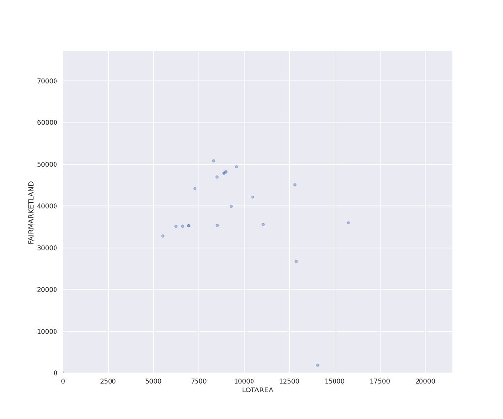

```python
# We create a new figure to make other figures in the notebook don't get modified
plt.figure()
zip_chart = zip_land(df, 15236)
plt.show()
```

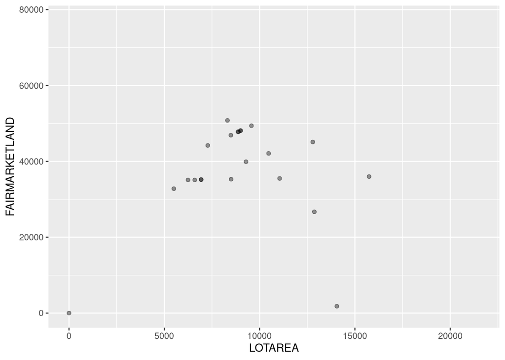

```r
zip_chart <- zip_land(df, 15236)
zip_chart
```

### Charting property values with seaborn

**Q8.** Create a DataFrame which contains only entries from `df` with a `SALEDESC` of `VALID SALE`. - Use the `.copy()` method to ensure you have a distinct DataFrame in memory

Call the new dataframe `sales`

```python
# Add your code below
sales = df[df.SALEDESC == 'VALID SALE'].copy()
```

**Q9.** Add a column to `sales` called `PITTSBURGH`, containing boolean values of `True` where `PROPERTYCITY` equals `PITTSBURGH` and `False` if not.

```python
sales['PITTSBURGH'] = sales['PROPERTYCITY'] == 'PITTSBURGH'
```

```r
sales <- df %>%
    filter(SALEDESC == 'VALID SALE') %>%
    mutate(PITTSBURGH = (PROPERTYCITY == "PITTSBURGH"))
```

**Q10.** Create a seaborn `.violinplot()` with the following properties:

`x` = `PITTSBURGH`  
`y` = `FAIRMARKETTOTAL`  
`data` = only entries from `sales` where `['BEDROOMS'] == 1`

*Put the `sns.type_of_plot(...)` statement after the `=` assignment sign; you will still see the resulting plot in the notebook, and KATE will be able to evaluate it.*

Call the new variable `pitts_violin`

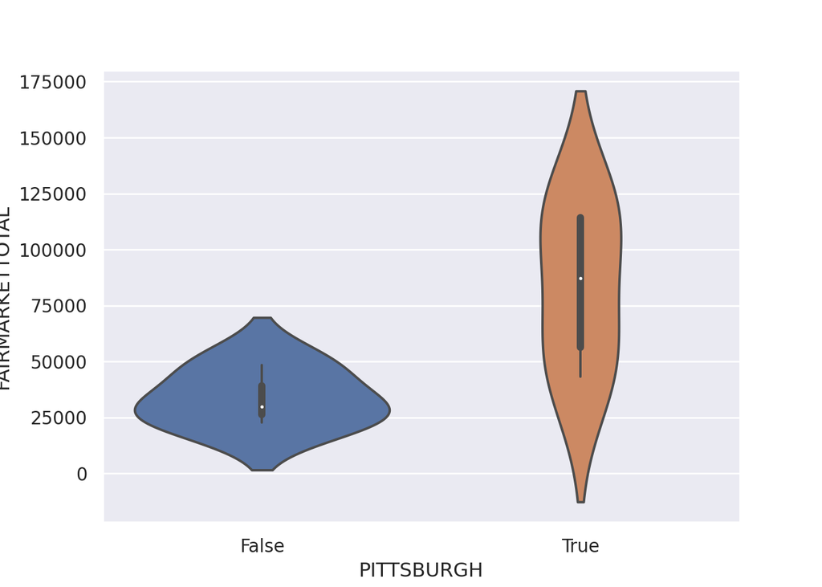

```python
# We create a new figure to make other figures in the notebook don't get modified
plt.figure()
onebeds = sales[sales['BEDROOMS'] == 1]

pitts_violin = sns.violinplot(x = 'PITTSBURGH', y = 'FAIRMARKETTOTAL', data = onebeds)
plt.show()
```

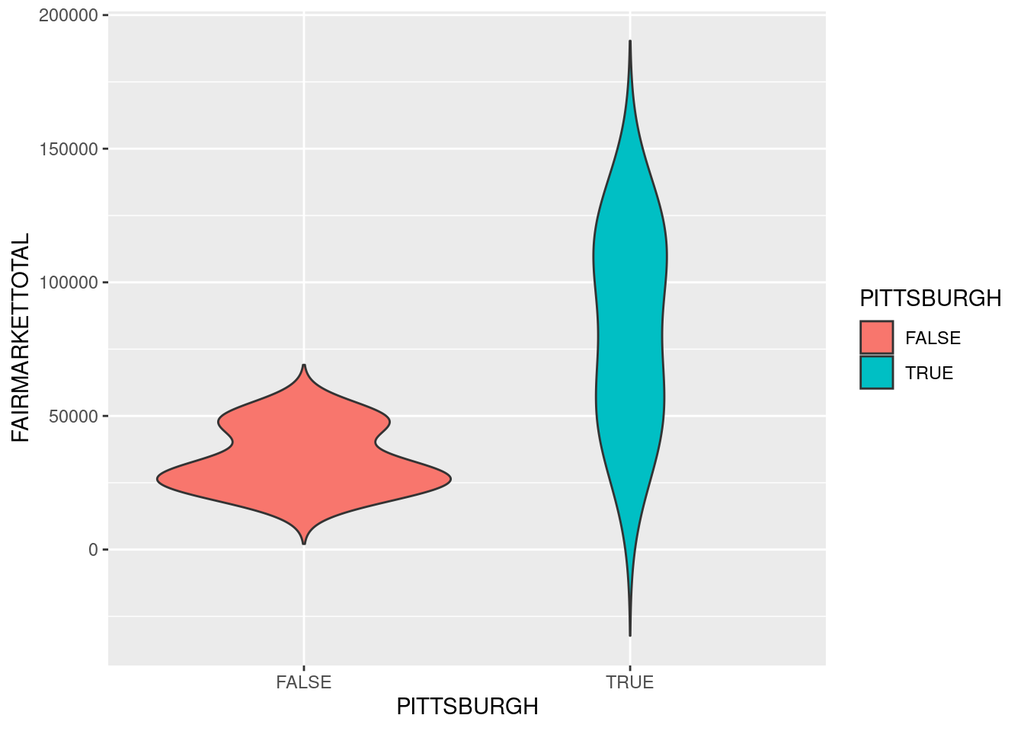

```r
onebeds <- sales %>%
    filter(BEDROOMS == 1)

pitts_violin <- onebeds %>%
    ggplot(aes(x = PITTSBURGH, y = FAIRMARKETTOTAL, fill = PITTSBURGH)) +
    geom_violin(trim = FALSE)

pitts_violin
```

**Q11.** Create a seaborn `.regplot()` with the following properties:

`x` = `SALEPRICE`  
`y` = `FAIRMARKETTOTAL`  
`data` = only entries from `sales` where `['GRADEDESC'] == 'EXCELLENT'`

Call the new variable `exc_reg`

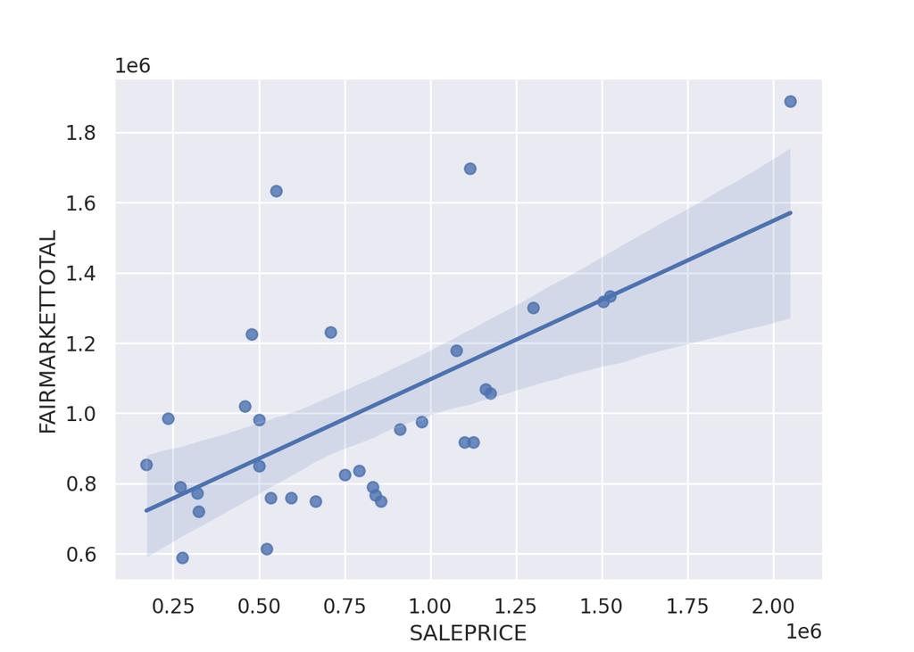

```python
# We create a new figure to make other figures in the notebook don't get modified
plt.figure()
exc_grade = sales[sales['GRADEDESC'] == 'EXCELLENT']
exc_reg = sns.regplot(x = 'SALEPRICE', y = 'FAIRMARKETTOTAL', data = exc_grade)
plt.show()
```

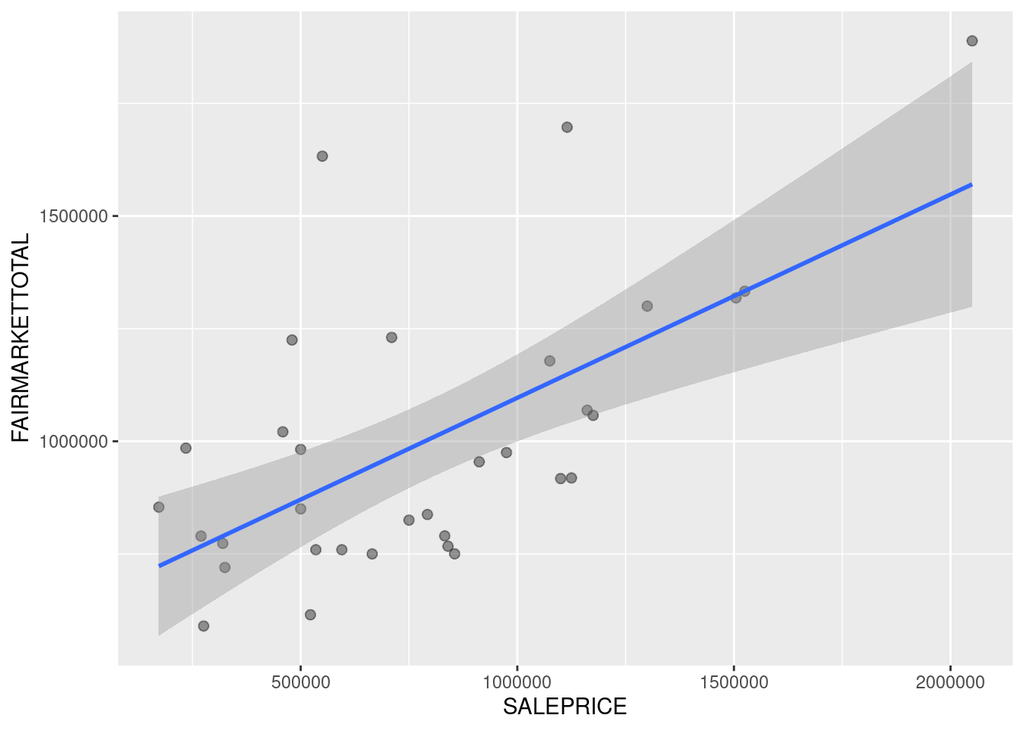

```r
exc_grade <- sales %>%
    filter(GRADEDESC == "EXCELLENT")

exc_reg <- exc_grade %>%
    ggplot(aes(x = SALEPRICE, y = FAIRMARKETTOTAL)) +
    geom_point(alpha = 0.4, size = 2) +
    geom_smooth(method = "lm")

exc_reg
```

**Q12.** Create a DataFrame called `bus` which contains only entries from `sales` where `CLASSDESC` `.isin(['COMMERCIAL', 'INDUSTRIAL', 'AGRICULTURAL'])`.

```python
bus = sales[sales['CLASSDESC'].isin(['COMMERCIAL', 'INDUSTRIAL', 'AGRICULTURAL'])]
```

```r
bus <- sales %>%
    filter(CLASSDESC %in% c('COMMERCIAL', 'INDUSTRIAL', 'AGRICULTURAL'))
```

**Q13.** Create a DataFrame using the `.groupby()` method on the `bus` DataFrame with the following properties:

- Data grouped by `['CLASSDESC', 'PITTSBURGH']` where the values are of the `.mean()` of `FAIRMARKETTOTAL`
- Use `.reset_index()` so that a DataFrame is created
- Use `.sort_values(by='FAIRMARKETTOTAL')` to order it

Call the new dataframe `bus_value`

```python
bus_value = bus \
.groupby(['CLASSDESC', 'PITTSBURGH'])['FAIRMARKETTOTAL']. \
mean(). \
reset_index(). \
sort_values(by = 'FAIRMARKETTOTAL')
bus_value
```

```
##     CLASSDESC  PITTSBURGH  FAIRMARKETTOTAL
## 0  COMMERCIAL       False         191475.0
## 2  INDUSTRIAL       False         362800.0
## 1  COMMERCIAL        True         674725.0
```

```r
bus_value <- bus %>%
    group_by(CLASSDESC, PITTSBURGH) %>%
    summarise(FAIRMARKETTOTAL = mean(FAIRMARKETTOTAL, na.rm = TRUE)) %>%
    arrange(FAIRMARKETTOTAL)
bus_value
```

```
## # A tibble: 3 × 3
## # Groups:   CLASSDESC [2]
##   CLASSDESC  PITTSBURGH FAIRMARKETTOTAL
##   <chr>      <lgl>                <dbl>
## 1 COMMERCIAL FALSE               191475
## 2 INDUSTRIAL FALSE               362800
## 3 COMMERCIAL TRUE                674725
```

**Q14.** Create a seaborn `.barplot()` with the following properties: - `x` = `CLASSDESC` - `y` = `FAIRMARKETTOTAL` - `hue` = `PITTSBURGH` - `data` = `bus_value`

Call the new variable `bus_bar`

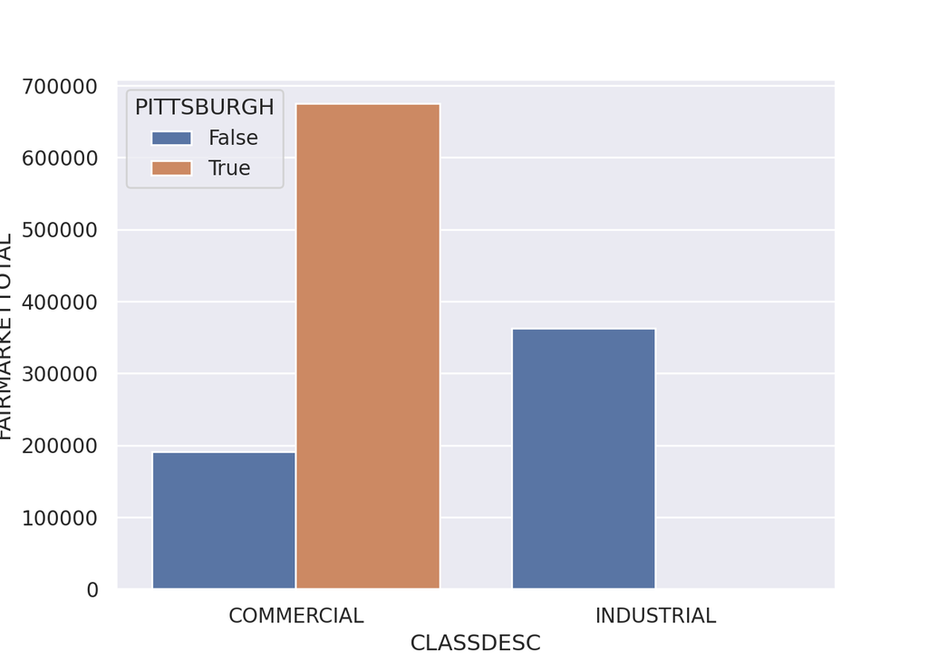

```python
# We create a new figure to make other figures in the notebook don't get modified
plt.figure()
bus_bar =  sns.barplot(x = 'CLASSDESC', y = 'FAIRMARKETTOTAL', hue = 'PITTSBURGH', data = bus_value)
plt.show()
```

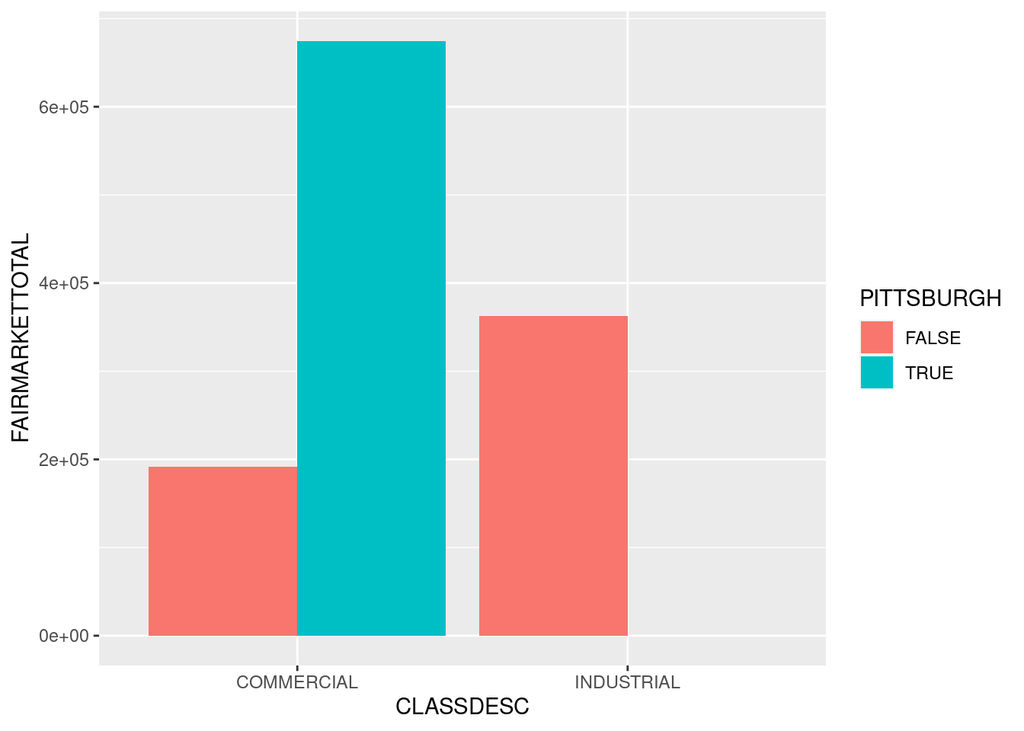

```r
#ggplot
bus_value %>%
    ggplot(aes(x = CLASSDESC,
               y = FAIRMARKETTOTAL,
               fill = PITTSBURGH,
               group = PITTSBURGH)) +
    geom_col(position = position_dodge(preserve = "single"))
```

```r
#highcharts
bus_value %>%
    # ungroup() %>%
    hchart("column", hcaes(x = CLASSDESC,
                           y = FAIRMARKETTOTAL,
                           color = PITTSBURGH,
                           group = PITTSBURGH))
```

[interactive chart not shown]